# PUC MINAS

## Pós Graduação em Ciência de Dados e Big Data (2019-2020)

### Trabalho de Conclusão de Curso

### Aluna: Maria da Glória dos Santos Batista de Oliveira

**Leitura dos dados e importação das bibliotecas utilizadas**

Para iniciar o trabalho, primeiramente é necessário fazer download dos datasets informados previamente. Assim o documento poderá ser lido sem que qualquer problema ocorra.

No código a seguir, as importações das bibliotecas utilizadas e a definição dos métodos para facilitar a visualização dos dados e exibição de gráficos de value counts no Pandas.

```python
# Imports das bibliotecas utilizadas

import pandas as pd
import numpy as np

# Visualização
import matplotlib.pyplot as plt
%matplotlib inline
import seaborn as sns
import plotly.express as px
import plotly.graph_objects as go
import folium
from folium import plugins

# Manipulando o tamanho padrão do plot
plt.rcParams['figure.figsize'] = 8, 5

# Não exibir as mensagens de warnings
import warnings
warnings.filterwarnings('ignore')
```

Vamos realizar as importações dos datasets utilizados:

```python
# Import do dataset utilizado

qtd_ativos = '../datasets_tratados/df_qtd_ativos.csv'

# filtrando as colunas que serão utilizadas:
lista_colunas = ["date", "case", "count"]

df_qtd_ativos = pd.read_csv(qtd_ativos, sep=',',parse_dates=['date'], usecols=lista_colunas)
```

```python
# Import do dataset utilizado

qtd_monitorados = '../datasets_tratados/df_qtd_monitorados.csv'

# filtrando as colunas que serão utilizadas:
lista_colunas = ["date", "case", "count"]

df_qtd_monitorados = pd.read_csv(qtd_monitorados, sep=',', parse_dates=['date'], usecols=lista_colunas)
```

```python
# Import do dataset utilizado

qtd_mortos = '../datasets_tratados/df_qtd_mortos.csv'

# filtrando as colunas que serão utilizadas:
lista_colunas = ["date", "case", "count"]

df_qtd_mortos = pd.read_csv(qtd_mortos, sep=',', parse_dates=['date'], usecols=lista_colunas)
```

```python
# Import do dataset utilizado

qtd_recuperados = '../datasets_tratados/df_qtd_recuperados.csv'

# filtrando as colunas que serão utilizadas:
lista_colunas = ["date", "case", "count"]

df_qtd_recuperados = pd.read_csv(qtd_recuperados, sep=',', parse_dates=['date'], usecols=lista_colunas)
```

```python
# Import do dataset utilizado

casos_agrupados = '../datasets_tratados/df_casos_agrupados.csv'

# filtrando as colunas que serão utilizadas:
lista_colunas = ["date", "case", "count"]

df_casos_agrupados = pd.read_csv(casos_agrupados, sep=',', parse_dates=['date'], usecols=lista_colunas)
```

#### Visualizando os datasets importados:

```python
# Visualizando o dataset:

df_qtd_ativos.head(5)
```

|  | date | case | count |
| --- | --- | --- | --- |
| 0 | 2020-02-25 | active | 0 |
| 1 | 2020-02-26 | active | 1 |
| 2 | 2020-02-27 | active | 1 |
| 3 | 2020-02-28 | active | 1 |
| 4 | 2020-02-29 | active | 2 |

```python
# Visualizando o dataset:

df_qtd_monitorados.head(5)
```

|  | date | case | count |
| --- | --- | --- | --- |
| 0 | 2020-02-25 | monitoring | 0 |
| 1 | 2020-02-26 | monitoring | 0 |
| 2 | 2020-02-27 | monitoring | 0 |
| 3 | 2020-02-28 | monitoring | 0 |
| 4 | 2020-02-29 | monitoring | 0 |

```python
# Visualizando o dataset:

df_qtd_mortos.head(5)
```

|  | date | case | count |
| --- | --- | --- | --- |
| 0 | 2020-02-25 | deaths | 0 |
| 1 | 2020-02-26 | deaths | 0 |
| 2 | 2020-02-27 | deaths | 0 |
| 3 | 2020-02-28 | deaths | 0 |
| 4 | 2020-02-29 | deaths | 0 |

```python
# Visualizando o dataset:

df_qtd_recuperados.head(5)
```

|  | date | case | count |
| --- | --- | --- | --- |
| 0 | 2020-02-25 | recovered | 0 |
| 1 | 2020-02-26 | recovered | 0 |
| 2 | 2020-02-27 | recovered | 0 |
| 3 | 2020-02-28 | recovered | 0 |
| 4 | 2020-02-29 | recovered | 0 |

```python
# Visualizando o dataset:

df_casos_agrupados.head(5)
```

|  | date | case | count |
| --- | --- | --- | --- |
| 0 | 2020-02-25 | recovered | 0 |
| 1 | 2020-02-26 | recovered | 0 |
| 2 | 2020-02-27 | recovered | 0 |
| 3 | 2020-02-28 | recovered | 0 |
| 4 | 2020-02-29 | recovered | 0 |

#### 1 - Quantas pessoas foram infectadas com esta doença?

Para uma análise melhor dos dados, vamos gerar um dataframe exclusivo para responder esta pergunta.

Visualizando o gráfico que mostra a quantidade de pessoas doentes por mês:

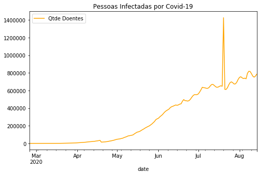

```python
# Gerando o gráfico de pessoas doentes

df_qtd_ativos.plot(kind='line',x='date',y='count',color='orange',
                   label='Qtde Doentes', title='Pessoas Infectadas por Covid-19')
plt.show()
```

#### 2 - Quantas pessoas estão sendo monitoradas com suspeita dessa doença?

Para uma realização de uma melhor análise dos dados, vamos gerar um dataframe exclusivo para responder esta pergunta.

Visualizando o gráfico que mostra a quantidade de pessoas monitoradas por data:

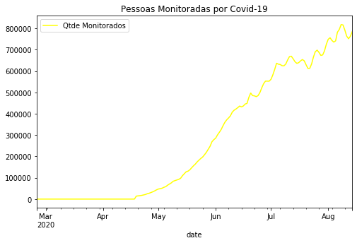

```python
# Gerando o gráfico de pessoas monitoradas

df_qtd_monitorados.plot(kind='line',x='date',y='count',color='yellow',
                        label='Qtde Monitorados', title='Pessoas Monitoradas por Covid-19')
plt.show()
```

#### 3 - Quantas pessoas morreram com esta doença?

Para um melhor entendimento dos dados, vamos gerar um dataframe exclusivo para responder esta pergunta.

Visualizando o gráfico que mostra a quantidade de pessoas mortas por data:

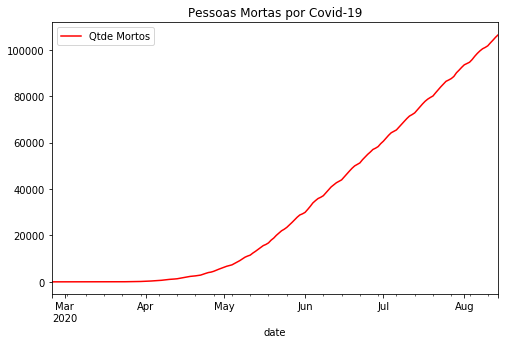

```python
# Gerando o gráfico de pessoas mortas

df_qtd_mortos.plot(kind='line',x='date',y='count',color='red',
                   label='Qtde Mortos', title='Pessoas Mortas por Covid-19')
plt.show()
```

#### 4 - Quantas pessoas se recuperaram desta doença?

Para uma melhor compreensão dos dados, vamos gerar um dataframe exclusivo para responder esta pergunta.

Visualizando o gráfico que mostra a quantidade de pessoas recuperadas por data:

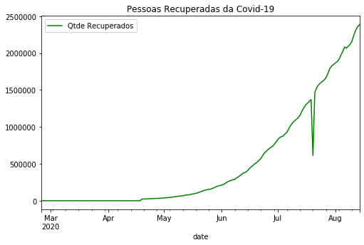

```python
# Gerando o gráfico de pessoas recuperadas

df_qtd_recuperados.plot(kind='line',x='date',y='count',color='green',
                        label='Qtde Recuperados', title='Pessoas Recuperadas da Covid-19')
plt.show()
```

#### 5 - Comparação entre as quantidades de Doentes, Monitorados, Mortos e Recuperados

Vamos realizar uma comparação em forma de gráfico com todos os dataframes gerados até o momento.

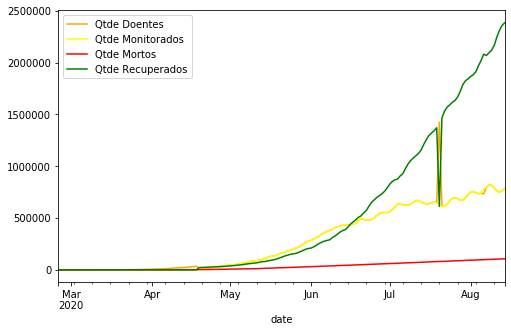

```python
# gca para obter eixo atual

ax = plt.gca()

df_qtd_ativos.plot(kind='line',x='date',y='count',color='orange',label='Qtde Doentes', ax=ax)
df_qtd_monitorados.plot(kind='line',x='date',y='count',color='yellow',label='Qtde Monitorados', ax=ax)
df_qtd_mortos.plot(kind='line',x='date',y='count',color='red',label='Qtde Mortos', ax=ax)
df_qtd_recuperados.plot(kind='line',x='date',y='count',color='green',label='Qtde Recuperados',ax=ax)

plt.show()
```

```python
# Definindo as cores para cada caso de Covid-19 mostrado no gráfico abaixo

recuperados = 'green'
mortes = 'red'
ativos = 'orange'
monitorados = 'yellow'

fig = px.area(df_casos_agrupados,
              x="date",
              y="count",
              color='case',
              height=600,
              title='Casos ao longo deste ano',
              color_discrete_sequence = [recuperados, mortes, ativos, monitorados])
fig.update_layout(xaxis_rangeslider_visible=True)
fig.show()
```

[interactive chart not shown]